# Esplorative Data Analysis

#### Esplorative Data Analysis

###### Packages

```python
import matplotlib.pyplot as plt
from math import pi
import seaborn as sns
import pandas as pd
import numpy as np
from sklearn import preprocessing, model_selection
from sklearn import decomposition
from sklearn.model_selection import train_test_split
from sklearn import metrics
from matplotlib import rcParams
from matplotlib import pyplot
```

#### Info Dataset

```python
df = pd.read_csv(r"Churn_Banking_Modeling.csv")
df.info()
```

```
<class 'pandas.core.frame.DataFrame'>
RangeIndex: 377369 entries, 0 to 377368
Data columns (total 43 columns):
 #   Column                               Non-Null Count   Dtype
---  ------                               --------------   -----
 0   Id_Cliente                           377369 non-null  int64
 1   Flag_Richiesta_Estinzione_cc         377369 non-null  object
 2   Imp_Valore_del_Cliente               377369 non-null  float64
 3   Flag_Apertura_Conto_Online           377369 non-null  int64
 4   Flag_Possesso_piu_Conti              377369 non-null  int64
 5   Eta                                  377362 non-null  float64
 6   Provincia_Domicilio                  356181 non-null  object
 7   Provincia_Residenza                  357897 non-null  object
 8   Anno_Apertura_primo_Conto            377369 non-null  float64
 9   Professione                          341172 non-null  object
```

[output cut: 35 more lines]

###### Categorical Features dtype transformation in the type object

```python
for col in df.columns:
    if col.startswith('Flag'):
        df[col] = df[col].astype('object')


numeric_variables_count = len(df.select_dtypes(include=['number']).columns)
categorical_variables_count = len(df.select_dtypes(include=['object']).columns)

print("number of numeric features",numeric_variables_count)
print("number of categorical features",categorical_variables_count)
print(df.info())
```

```
number of numeric features 22
number of categorical features 21
<class 'pandas.core.frame.DataFrame'>
RangeIndex: 377369 entries, 0 to 377368
Data columns (total 43 columns):
 #   Column                               Non-Null Count   Dtype
---  ------                               --------------   -----
 0   Id_Cliente                           377369 non-null  int64
 1   Flag_Richiesta_Estinzione_cc         377369 non-null  object
 2   Imp_Valore_del_Cliente               377369 non-null  float64
 3   Flag_Apertura_Conto_Online           377369 non-null  object
 4   Flag_Possesso_piu_Conti              377369 non-null  object
 5   Eta                                  377362 non-null  float64
 6   Provincia_Domicilio                  356181 non-null  object
 7   Provincia_Residenza                  357897 non-null  object
```

[output cut: 38 more lines]

#### Missing Values

###### There are a lot of missing values for some instances, but the usage of particular Machine Learning techniques allowed us to not treat them, since this work will be done by the algorithm itself

```python
missing_values_count = df.isnull().sum()
print(df.isnull().sum())
```

```
Id_Cliente                                  0
Flag_Richiesta_Estinzione_cc                0
Imp_Valore_del_Cliente                      0
Flag_Apertura_Conto_Online                  0
Flag_Possesso_piu_Conti                     0
Eta                                         7
Provincia_Domicilio                     21188
Provincia_Residenza                     19472
Anno_Apertura_primo_Conto                   0
Professione                             36197
Imp_Reddito                            219893
Tipologia_Cliente                           0
Sesso                                       7
Profilo_MIFID                           49257
Imp_Canone_Pricing_cc                   27396
Imp_Bonifici_vs_Competitors            288655
Imp_Bonifici_vs_No_Competitors         176679
Num_Utenze_in_essere                   167432
Flag_Accredito_Stipendio                    0
Imp_Spending_Carta_Credito             164706
Imp_Spending_Bancomat                  176004
Num_Accessi_Sito                        50199
Num_Movimenti_Dispositivi               61605
Num_attivit�_trading                   290438
Var_Numero_Utenze                      159014
Flag_Mutuo                                  0
Flag_Prestito                               0
Flag_Giroconto                              0
Flag_Richiesta_info_chiusura_conto          0
Iscrizione_programma_Loyalty                0
Flag_Contatto_Call_Center                   0
Flag_variazione_Accredito_Stipendio    219893
Num_Punti_Programma_Loyalty            250130
Imp_Liquidit�_Attuale                       5
Imp_Gestito_attuale                    266181
Imp_Amministrato_attuale               189735
Imp_Liquidit�_Attuale_6m                   13
Imp_Gestito_attuale_6m                 266469
Imp_Amministrato_attuale_6m            191071
Flag_Trasferimento_Titoli_Out               0
Flag_Rifiuto_Carte                          0
Flag_Rifiuto_Prestiti                       0
Flag_Disattivazione_RID                     0
dtype: int64
```

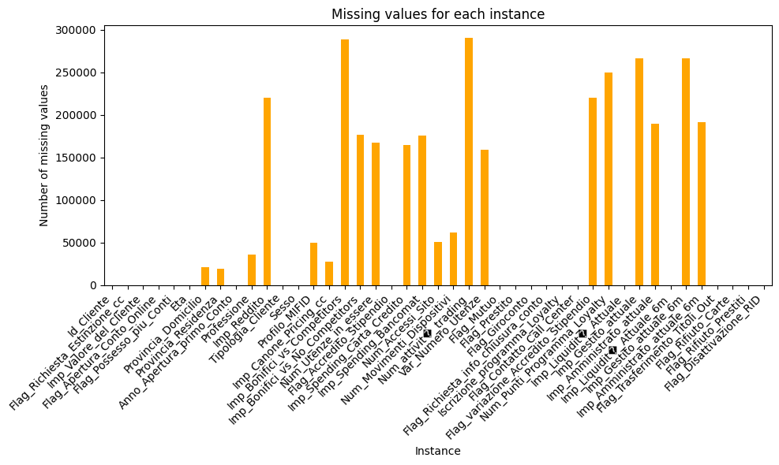

```python
plt.figure(figsize=(10, 6))
missing_values_count.plot(kind='bar',color="orange")
plt.title('Missing values for each instance')
plt.xlabel('Instance')
plt.ylabel('Number of missing values')
plt.xticks(rotation=45, ha='right')
plt.tight_layout()
plt.show()
```

#### The Target

###### The target is Flag_Richiesta_Estinzione_cc, it is a categorical binary feature with class 'yes' if the client has the willingness to leave the bank, then 'no' if he or her prefers to remain

```python
df["Flag_Richiesta_Estinzione_cc"].describe()
```

```
count     377369
unique         2
top           no
freq      375386
Name: Flag_Richiesta_Estinzione_cc, dtype: object
```

```python
df["Flag_Richiesta_Estinzione_cc"].value_counts()
```

```
Flag_Richiesta_Estinzione_cc
no    375386
si      1983
Name: count, dtype: int64
```

###### The frequencies of the target are unbalanced: 99.5% for 'no' and 0.5% for 'yes'

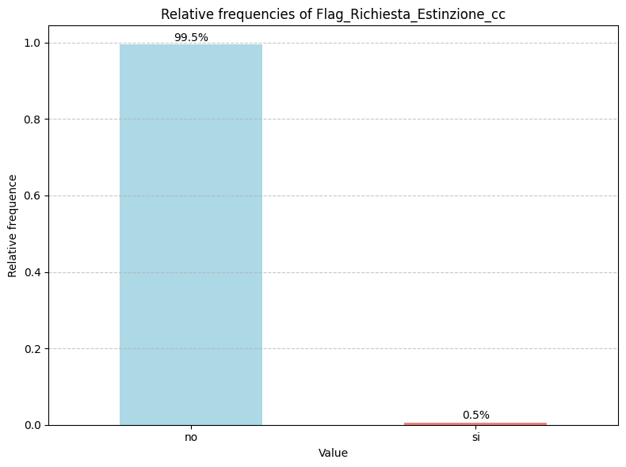

```python
relative_frequencies = df['Flag_Richiesta_Estinzione_cc'].value_counts(normalize=True)
plt.figure(figsize=(8, 6))
bars = relative_frequencies.plot(kind='bar', color=['lightblue', 'lightcoral'])

# Add percentage on the bars
for i, v in enumerate(relative_frequencies):
    plt.text(i, v + 0.01, f"{v*100:.1f}%", ha='center')

plt.title('Relative frequencies of Flag_Richiesta_Estinzione_cc')
plt.xlabel('Value')
plt.ylabel('Relative frequence')
plt.xticks(rotation=0)  #slant of the labels
plt.grid(axis='y', linestyle='--', alpha=0.7)  # Add a grid for the target
plt.tight_layout()
plt.show()
```

#### Univariate Analysis for categorical features

###### Most customers are Bankers o Investitors, they represent togheter the 90% of customers.

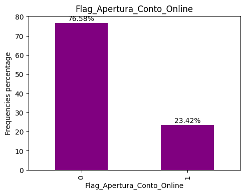

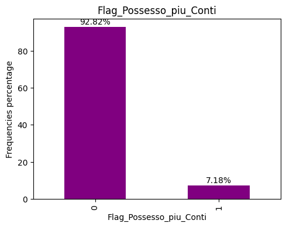

[figure not shown]

[figure not shown]

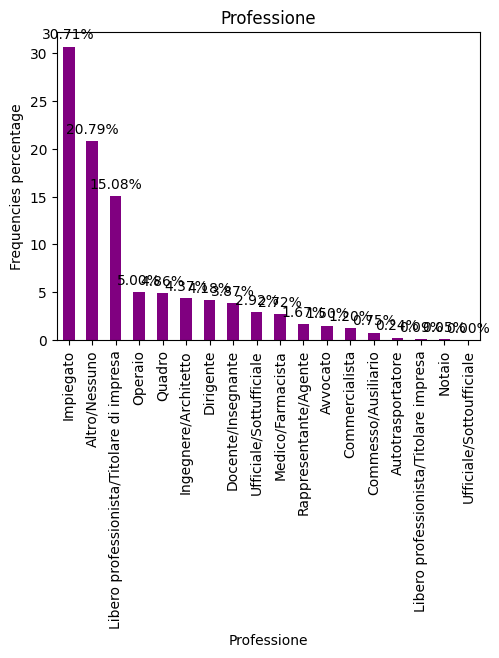

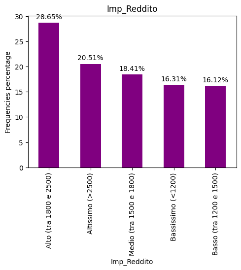

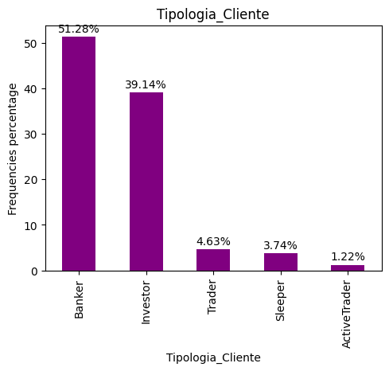

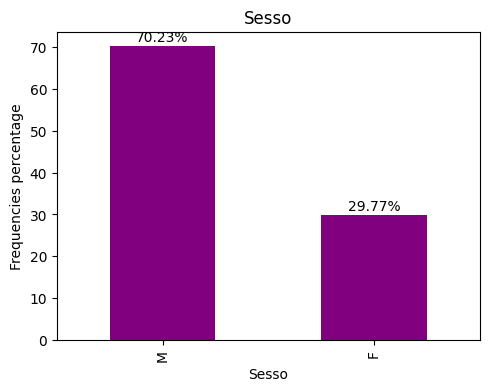

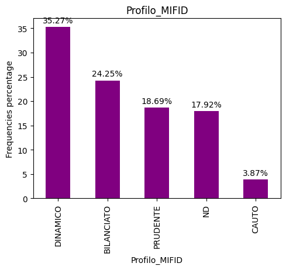

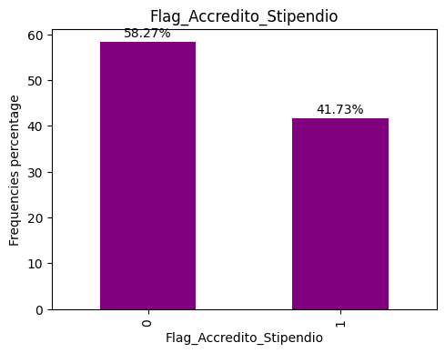

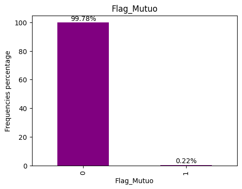

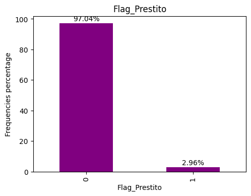

[8 more figures not shown]

```python
cat_var = df.select_dtypes(include=["object"]).columns.drop("Flag_Richiesta_Estinzione_cc")


for column in cat_var:
    plt.figure(figsize=(12, 4))
    plt.subplot(121)

    relative_freq = df[column].value_counts(normalize=True)

    percent_freq = relative_freq * 100
    percent_freq.plot(kind="bar", color="purple")
    plt.xlabel(column)
    plt.ylabel("Frequencies percentage")
    plt.title(column)


    for i, v in enumerate(percent_freq):
        plt.text(i, v + 0.5, f'{v:.2f}%', ha='center', va='bottom')

    plt.show()
```

#### Bivariate Analysis of categorical feature

###### Here there is the analysis of the relation between the target and the most interesting categorical features.

###### Since the high presence of the 'no' modality in the target, there are other barplots focused only about the 'yes' modality too.

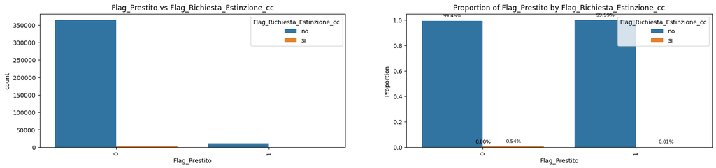

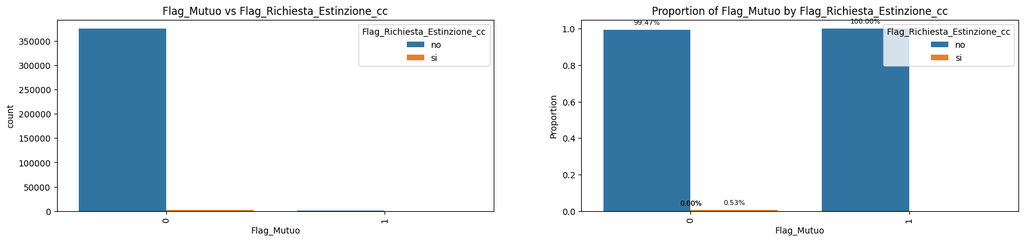

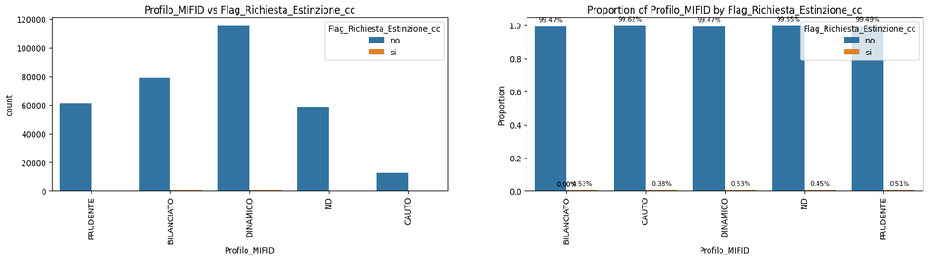

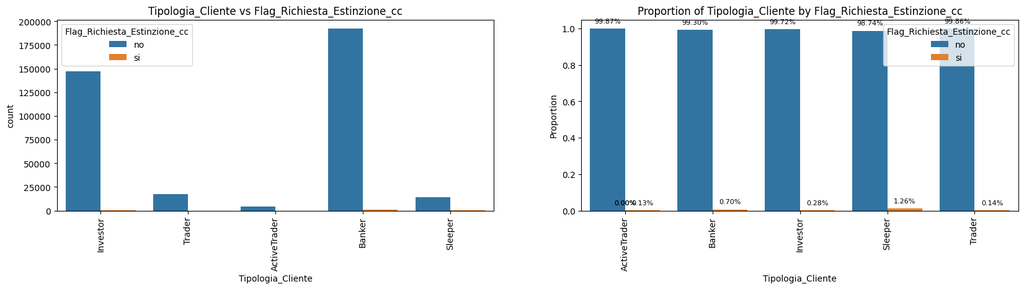

[figure not shown]

```python
cat_var1 = df[['Flag_Prestito','Flag_Mutuo','Profilo_MIFID','Tipologia_Cliente','Professione']]
for column in cat_var1:
    # Crea una nuova figura per ogni variabile categorica
    plt.figure(figsize=(20, 4))

    # Plot a sinistra
    plt.subplot(121)
    sns.countplot(data=df, x=column, hue="Flag_Richiesta_Estinzione_cc")
    plt.title(f"{column} vs Flag_Richiesta_Estinzione_cc")
    plt.xticks(rotation=90)

    # Aggiungi un subplot per la proporzione
    plt.subplot(122)
    prop_df = (df.groupby(column)["Flag_Richiesta_Estinzione_cc"]
               .value_counts(normalize=True)
               .rename("prop")
               .reset_index())
    sns.barplot(data=prop_df, x=column, y="prop", hue="Flag_Richiesta_Estinzione_cc")
    plt.title(f"Proportion of {column} by Flag_Richiesta_Estinzione_cc")
    plt.xticks(rotation=90)
    plt.ylabel("Proportion")

    # Annotazioni delle percentuali sopra le barre
    for p in plt.gca().patches:
        height = p.get_height()
        plt.gca().annotate(f'{height:.2%}', (p.get_x() + p.get_width() / 2., height),
                           ha='center', va='bottom', fontsize=8, color='black', xytext=(0, 5),
                           textcoords='offset points')

plt.tight_layout()
plt.show()
```

###### The 'yes' percentage of Flag_Richiesta_Estinzione_cc in the modalities of Flag_Prestito is around 100%: this means that a customer with no loans could leave the bank, while a customer with active loans almost certaintly won't leave the bank. The same is for the feature Flag_Mutuo

```python
count_estinzione = df[df['Flag_Prestito'] == 1].shape[0]
count_both = df[(df['Flag_Richiesta_Estinzione_cc'] == 'si') & (df['Flag_Prestito'] == 1)].shape[0]

count_estinzione2 = df[df['Flag_Mutuo'] == -1].shape[0]
count_both2 = df[(df['Flag_Richiesta_Estinzione_cc'] == 'si') & (df['Flag_variazione_Accredito_Stipendio'] ==-1)].shape[0]

print('Absolute frequencies for yes of Flag_Prestito: ', count_estinzione, count_both)
print('Absolute frequencies for yes of Flag_Mutuo: ',count_estinzione2, count_both2)
```

```
Absolute frequencies for yes of Flag_Prestito:  11165 1
Absolute frequencies for yes of Flag_Mutuo:  0 232
```

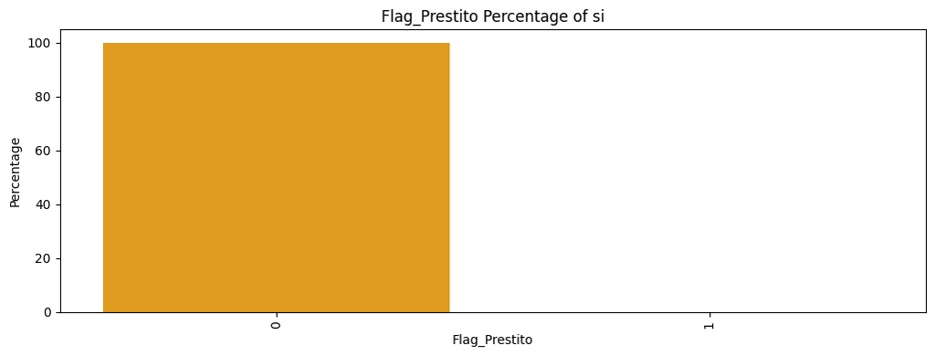

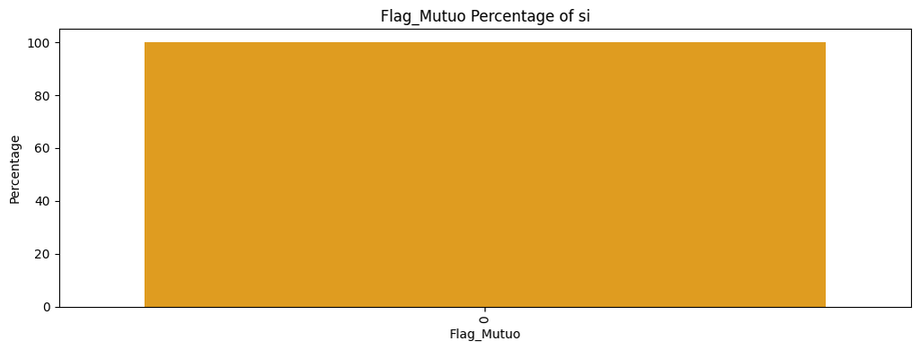

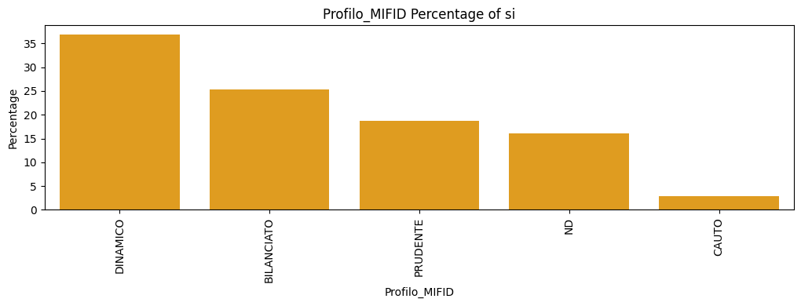

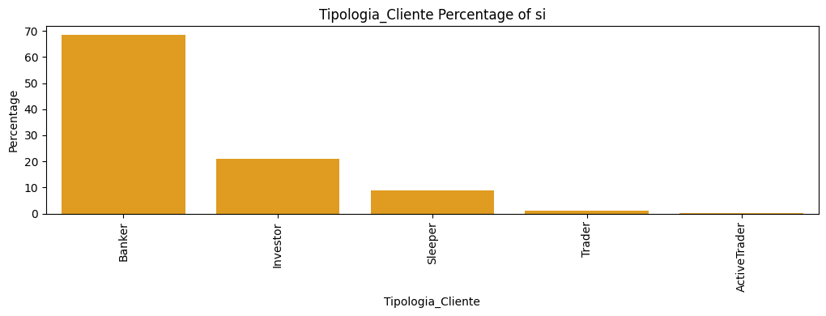

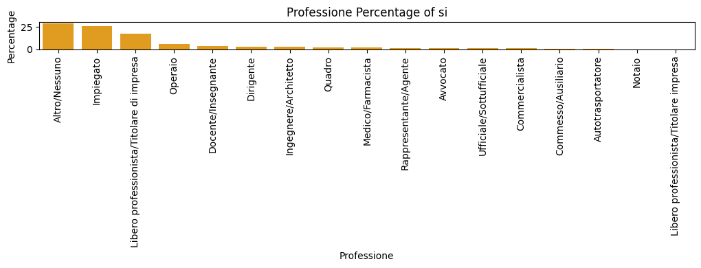

```python
cat_var1 = df[['Flag_Prestito','Flag_Mutuo','Profilo_MIFID', 'Tipologia_Cliente', 'Professione']]
target_categories = ['si']  # Solo 'si' per la variabile target

for category in target_categories:
    for column in cat_var1:
        plt.figure(figsize=(20, 4))

        # Relative frequencies for 'yes'
        freq_table = df[df['Flag_Richiesta_Estinzione_cc'] == category][column].value_counts()
        total = freq_table.sum()
        percentages = (freq_table / total) * 100

        plt.subplot(122)
        sns.barplot(x=percentages.index, y=percentages.values, color='orange')
        plt.title(f"{column} Percentage of {category}")
        plt.xlabel(column)
        plt.ylabel('Percentage')
        plt.xticks(rotation=90)
        plt.tight_layout()

plt.show()
```

#### Univariate analysis of numerical features

###### Some features have a strong asymettric distribution, so later we will consider the possibility to use the logaritmic scale. For example, Bonifici_vs_no_Competitors has a lot of values next to 0.

```python
df.describe(include=['int64', 'float64'])
```

|  | Id_Cliente | Imp_Valore_del_Cliente | Eta | Anno_Apertura_primo_Conto | Imp_Canone_Pricing_cc | Imp_Bonifici_vs_Competitors | Imp_Bonifici_vs_No_Competitors | Num_Utenze_in_essere | Imp_Spending_Carta_Credito | Imp_Spending_Bancomat | ... | Num_attivit�_trading | Var_Numero_Utenze | Iscrizione_programma_Loyalty | Num_Punti_Programma_Loyalty | Imp_Liquidit�_Attuale | Imp_Gestito_attuale | Imp_Amministrato_attuale | Imp_Liquidit�_Attuale_6m | Imp_Gestito_attuale_6m | Imp_Amministrato_attuale_6m |
| --- | --- | --- | --- | --- | --- | --- | --- | --- | --- | --- | --- | --- | --- | --- | --- | --- | --- | --- | --- | --- | --- |
| count | 377369.000000 | 377369.000000 | 377362.000000 | 377369.000000 | 349973.000000 | 8.871400e+04 | 2.006900e+05 | 209937.000000 | 212663.000000 | 201365.000000 | ... | 86931.000000 | 218355.000000 | 377369.000000 | 127239.000000 | 3.773640e+05 | 1.111880e+05 | 1.876340e+05 | 3.773560e+05 | 1.109000e+05 | 1.862980e+05 |
| mean | 277680.735847 | 644.662654 | 46.039890 | 2004.805750 | 0.903291 | 3.183130e+03 | 3.352734e+03 | 4.454517 | 503.149146 | 337.938624 | ... | 15.143344 | 0.198044 | 0.337174 | 1045.617303 | 1.513478e+04 | 6.770461e+04 | 7.614477e+04 | 1.532084e+04 | 6.554481e+04 | 7.233862e+04 |
| std | 160279.531097 | 2928.725757 | 13.146689 | 3.288509 | 1.825685 | 1.423111e+04 | 1.511987e+04 | 3.636854 | 510.779493 | 510.884365 | ... | 78.764646 | 1.071767 | 0.472745 | 3515.585204 | 5.204623e+04 | 1.940914e+05 | 2.669638e+05 | 5.201275e+04 | 1.780930e+05 | 2.637481e+05 |
| min | 2.000000 | 0.000000 | 3.000000 | 1994.000000 | 0.000000 | 1.000000e-02 | 1.000000e-02 | 1.000000 | 0.010000 | 0.010000 | ... | 1.000000 | -26.000000 | 0.000000 | -50.000000 | -2.998609e+06 | 0.000000e+00 | 0.000000e+00 | -2.990061e+06 | 0.000000e+00 | 0.000000e+00 |
| 25% | 138834.000000 | 46.870000 | 37.000000 | 2002.000000 | 0.000000 | 1.575825e+02 | 3.500000e+02 | 2.000000 | 174.649167 | 130.670000 | ... | 1.000000 | 0.000000 | 0.000000 | 150.000000 | 6.292100e+02 | 7.880375e+03 | 4.966840e+03 | 6.313775e+02 | 7.808850e+03 | 4.937938e+03 |
| 50% | 277965.000000 | 97.270000 | 43.000000 | 2005.000000 | 0.000000 | 4.790000e+02 | 8.058555e+02 | 3.000000 | 363.346666 | 261.422500 | ... | 2.000000 | 0.000000 | 0.000000 | 495.000000 | 3.850860e+03 | 2.329358e+04 | 2.084153e+04 | 3.788385e+03 | 2.284953e+04 | 2.016169e+04 |
| 75% | 416378.000000 | 370.320000 | 54.000000 | 2008.000000 | 0.325000 | 1.500000e+03 | 2.047996e+03 | 6.000000 | 669.673333 | 461.661666 | ... | 6.000000 | 0.000000 | 1.000000 | 1065.000000 | 1.417872e+04 | 6.469545e+04 | 6.766876e+04 | 1.397786e+04 | 6.297351e+04 | 6.434840e+04 |
| max | 555150.000000 | 377934.870000 | 132.000000 | 2010.000000 | 5.950000 | 1.100000e+06 | 1.130700e+06 | 40.000000 | 27621.971666 | 181522.121666 | ... | 6812.000000 | 25.000000 | 1.000000 | 427530.000000 | 1.686020e+07 | 1.736378e+07 | 4.808764e+07 | 1.486619e+07 | 1.838148e+07 | 5.715864e+07 |

8 rows × 22 columns

```python
import plotly.express as px

fig = px.histogram(df, x='Imp_Bonifici_vs_Competitors')
# Layout
fig.update_layout(
    xaxis_title='Value',
    yaxis_title='Frequence',
)
fig.show()
```

[output not shown]

```python
import plotly.express as px

fig = px.histogram(df, x='Imp_Bonifici_vs_No_Competitors')

# Layout
fig.update_layout(
    xaxis_title='Valore',
    yaxis_title='Frequenza',
)
fig.show()
```

[output not shown]

###### Imp_Valore_del_Cliente has a lot of zeros

```python
print('Numero di 0 per la variabile Imp_Valore_del_Cliente',df.loc[df['Imp_Valore_del_Cliente']==0.00,'Imp_Valore_del_Cliente'].count())
# Crea un istogramma orizzontale per una variabile specifica (ad esempio 'NomeVariabile')
fig = px.histogram(df, x='Imp_Valore_del_Cliente')

# Imposta il layout del grafico
fig.update_layout(
    xaxis_title='Valore',
    yaxis_title='Frequenza',
)
# Mostra il grafico
fig.show()
```

[output not shown]

```
Numero di 0 per la variabile Imp_Valore_del_Cliente 7798
```

#### Bivariate Analysis of numerical features

###### There are some features strictly correlated, in particular 'Imp_Amministrato_attuale' and 'Imp_Amministrato_attuale_6m' have a correlation over 0.9: very high. This was obvious in teory too since they explain the same thing in different time.

###### Imp_Gestito_attuale and Imp_attuale have higher values for customers who decide not to leave their account

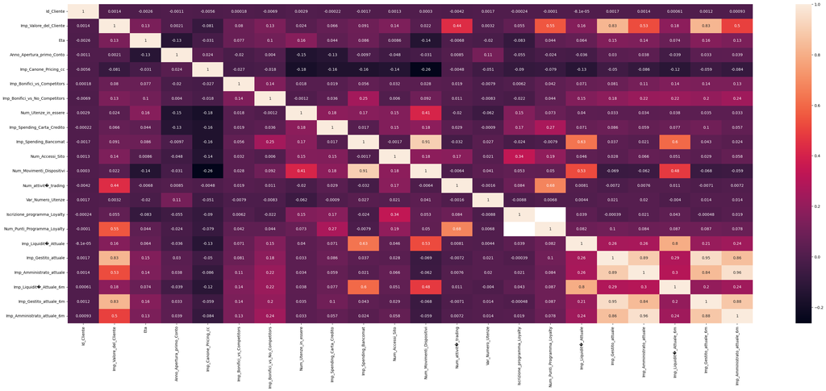

```python
numeric_df= df.select_dtypes(include=['int64','float64'])
plt.figure(figsize=(40,15))
sns.heatmap(numeric_df.corr(),annot=True)
```

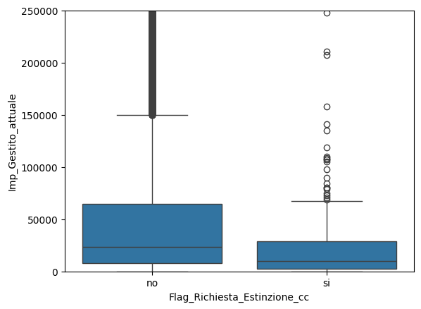

```python
sns.boxplot(x='Flag_Richiesta_Estinzione_cc', y='Imp_Gestito_attuale', data=df)

plt.xlabel('Flag_Richiesta_Estinzione_cc')
plt.ylabel('Imp_Gestito_attuale')

plt.ylim(0, 250000)
plt.show()
```

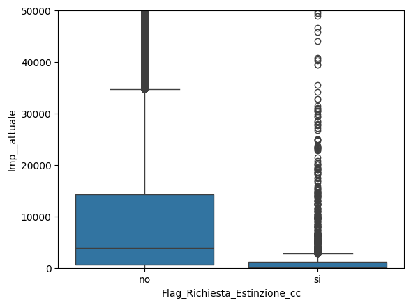

```python
sns.boxplot(x='Flag_Richiesta_Estinzione_cc', y='Imp_Liquidit�_Attuale', data=df)

plt.xlabel('Flag_Richiesta_Estinzione_cc')
plt.ylabel('Imp__attuale')

plt.ylim(0, 50000)
plt.show()
```

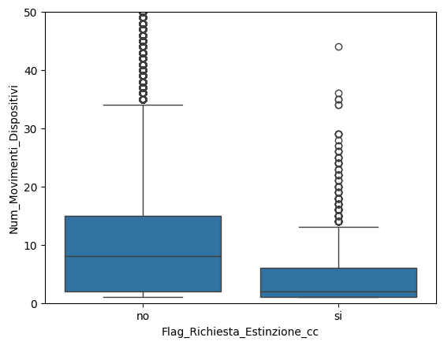

```python
sns.boxplot(x='Flag_Richiesta_Estinzione_cc', y='Num_Movimenti_Dispositivi', data=df)

plt.xlabel('Flag_Richiesta_Estinzione_cc')
plt.ylabel('Num_Movimenti_Dispositivi')

plt.ylim(0, 50)

plt.show()
```

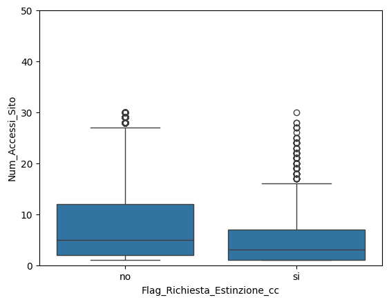

```python
sns.boxplot(x='Flag_Richiesta_Estinzione_cc', y='Num_Accessi_Sito', data=df)

plt.xlabel('Flag_Richiesta_Estinzione_cc')
plt.ylabel('Num_Accessi_Sito')

plt.ylim(0, 50)

plt.show()
```

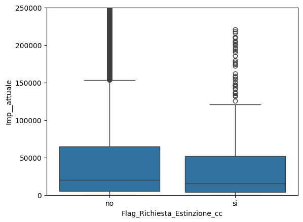

```python
sns.boxplot(x='Flag_Richiesta_Estinzione_cc', y='Imp_Amministrato_attuale_6m', data=df)

plt.xlabel('Flag_Richiesta_Estinzione_cc')
plt.ylabel('Imp__attuale')

plt.ylim(0, 250000)

plt.show()
```

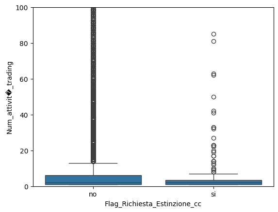

```python
sns.boxplot(x='Flag_Richiesta_Estinzione_cc', y='Num_attivit�_trading', data=df)

plt.xlabel('Flag_Richiesta_Estinzione_cc')
plt.ylabel('Num_attivit�_trading')

plt.ylim(0, 100)

plt.show()
```

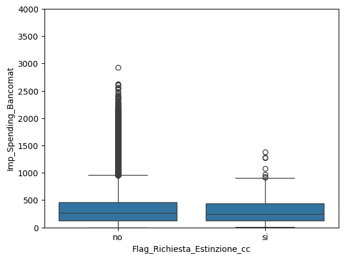

```python
sns.boxplot(x='Flag_Richiesta_Estinzione_cc', y='Imp_Spending_Bancomat', data=df)

plt.xlabel('Flag_Richiesta_Estinzione_cc')
plt.ylabel('Imp_Spending_Bancomat')

plt.ylim(0, 4000)

plt.show()
```